# Proyecto Final PDS

## Harrison Andres Henao Franco 1035227928

## Juan Camilo Chaparro Castellanos 1039466438

# Simulación de un sistema de radiocomunicación PSK

## Objetivo

Implementar un sistema de radiocomunicación PSK, profundizando en los conocimientos adqueridos en el trayecto del curso y de la carrera en general.

Se simulará una comunicación PSK y se analizará el estudio de la BER frente a la relación Eb/No, que dependen de distintas condiciones en el sistema de radiocomunicación.

Para realizar dicha simulación se seguirá la estructura de un sistema de comunicaciones digitales completo desde los bits que se desean transmitir hasta los bits que se reciben.

- Creación de un intervalo de evaluación con las relaciones de energía bit entre el ruido que se desea evaluar.
- Creación de un objeto que gestionará la modulación PSK con la librería commpy.
- Crear variables para guardar los valores del BER.
- Tener en cuenta todos los parámetros que se vayan a utilizar en el filtro.
- Crear una trama de bits aleatoria para el estudio.
- Modular dicha trama con el objeto de la modulación correspondiente.
- Sobremuestrear y filtrar los datos de entrada.
- Pasar la señal filtrada por un canal AWGN.
- Una vez haya pasado por el canal, se filtra y se submuestrea.
- Para terminar en el receptor, se demodula la señal y se comprueban los errores que hay de transmisión.

Para explicar el funcionamiento del sistema de radiocomunicación desarrollado se tomará como ejemplo una modulación QPSK ya que es el mismo para distintos tipos de modulaciones, lo único que varía es la constelación resultante y la expresión de la probabilidad de error.

## Datos a transmitir

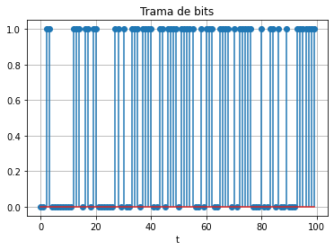

```python
import numpy as np
import matplotlib.pyplot as plt

Ns=100000
k=4

plt.figure()
plt.title('Trama de bits')
plt.xlabel('t')
x_tx = np.random.randint(0, 2, k*Ns) # Trama de bits binaria y aleatoria
t=np.arange(0,100)
plt.stem(t,x_tx[0:100])
plt.grid()
```

## Creación del objeto de la modulación

Tras crear un objeto con modulación PSK, al modular la trama de bits se obtiene la constelación de dicha modulación.

```python
from commpy import PSKModem

M=4
mod1=PSKModem(M)
```

[output not shown]

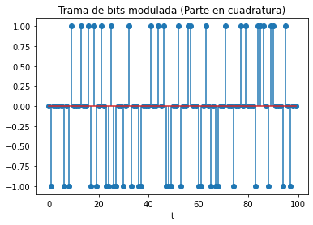

```python
m_tx=mod1.modulate(x_tx)
plt.figure()
plt.title('Trama de bits modulada (Parte en cuadratura)')
plt.xlabel('t')
plt.stem(np.arange(0,100),m_tx[0:100].real)
```

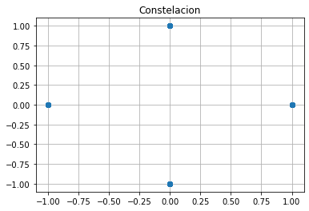

```python
plt.figure()
plt.title('Constelacion')
plt.plot(m_tx.real,m_tx.imag,"o")
plt.grid()
```

# Sobremuestreo de la señal

El siguiente paso consiste en sobremuestrear la señal, añadiendo ceros tras cada valor de la señal modulada de forma que se obtendrán los símbolos que se quieren mandar cada nsamp, que son las muestras por símbolo. El sobremuestreo se realiza para disponer de un mayor nivel de detalle en la forma de onda después de que la señal pase por el filtro conformador de pulso. Si se representa con saltos de nsamp, es decir, una muestra por símbolo, se obtienen que los símbolos transmitidos son solamente los que pertenecen a la constelación. En el tiempo quedará como la señal original, pero con ceros entre las muestras que son distintas de cero.

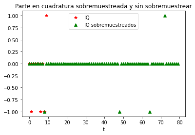

```python
from sk_dsp_comm.sigsys import downsample,upsample,cpx_awgn

Ts=1;
Fs=8; #Cuanto más suba Fs, más se acercará la BER a la gráfica teórica
nsamp=Fs*Ts; #Muestras por simbolo

y_tx=upsample(m_tx,nsamp)
plt.figure()
plt.xlabel('t')
plt.plot(np.arange(0,10),m_tx[0:10].real,"*r")
plt.title('Parte en cuadratura sobremuestreada y sin sobremuestrear')
plt.xlabel('t')
plt.plot(np.arange(0,10*nsamp),y_tx[0:10*nsamp],'^g')
plt.legend(('IQ','IQ sobremuestreados'))
```

Las dos señales son la misma solo que al realizarse un sobremuestrado zero-padding producirá que cuando pase por el filtro raíz de coseno alzado la señal de salida tendrá una forma de onda más suave y no tan abrupta como si no tuviese las muestras intermedias añadidas.

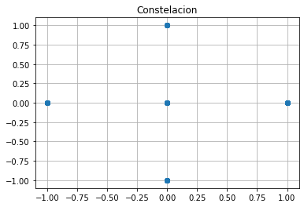

```python
plt.figure()
plt.title('Constelacion')
plt.plot(y_tx.real,y_tx.imag,"o")
plt.grid()
```

# Filtrado de la señal en transmisión

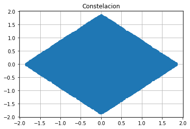

```python
from sk_dsp_comm.digitalcom import sqrt_rc_imp,rc_imp,q_fctn

##Parámetros para el diseño del filtro

Ts=1;
Fs=8; #Cuanto más suba Fs, más se acercará la BER a la gráfica teórica
nsamp=Fs*Ts; #Muestras por simbolo
alpha=0.22

##Diseño del filtro

filtro= sqrt_rc_imp(nsamp,alpha)
r_tx=np.convolve(y_tx,filtro,mode='same')

plt.figure()
plt.title('Constelacion')
plt.plot(r_tx.real,r_tx.imag,"o")
plt.grid()
```

Se ha diseñado el sistema con un filtro raíz de coseno alzado tanto en transmisor como en receptor por ser la opción más extendida en la implementación práctica de los sistemas de radiocomunicación, el filtrado se tiene que realizar siguiendo el criterio de Nyquist de la forma más aproximada posible ya que este es irrealizable por su no causalidad, por lo que se realizará mediante la familia del coseno alzado.

La señal se convoluciona con el filtro para prepararla para la transmisión, de modo que queda una señal continua en el tiempo

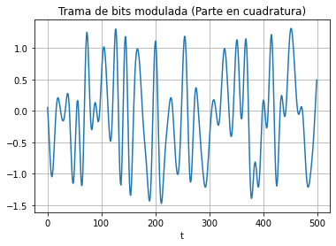

```python
plt.figure()
plt.title('Trama de bits modulada (Parte en cuadratura)')
plt.xlabel('t')
plt.plot(np.arange(0,500),r_tx.real[0:500])
plt.grid()
```

# Paso de la señal filtrada por un canal AWGN

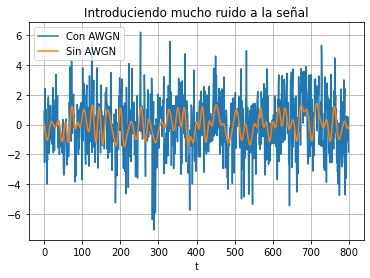

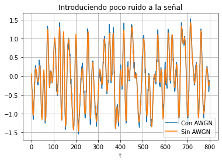

```python
from math import log,sin,pi,sqrt

#Pasar la señal por un canal AWGN PRUEBA 1
ebno=-5 #Con mucho ruido
#ebno=20 #Con poco ruido --> PROBARLO LOS DOS
error_sum=0;
esno = ebno + 10*log(k,10)
w1=cpx_awgn(r_tx,esno,nsamp)

plt.figure()
plt.title("Introduciendo mucho ruido a la señal")
plt.xlabel('t')
plt.plot(np.arange(0,100*nsamp),w1[0:100*nsamp])
plt.plot(np.arange(0,100*nsamp),r_tx[0:100*nsamp])
plt.legend(("Con AWGN","Sin AWGN"))
plt.grid()

#ebno=-5 #Con mucho ruido
ebno=20 #Con poco ruido --> PROBARLO LOS DOS
error_sum=0;
esno = ebno + 10*log(k,10)
w1=cpx_awgn(r_tx,esno,nsamp)


plt.figure()
plt.title("Introduciendo poco ruido a la señal")
plt.xlabel('t')
plt.plot(np.arange(0,100*nsamp),w1[0:100*nsamp])
plt.plot(np.arange(0,100*nsamp),r_tx[0:100*nsamp])
plt.legend(("Con AWGN","Sin AWGN"))
plt.grid()
```

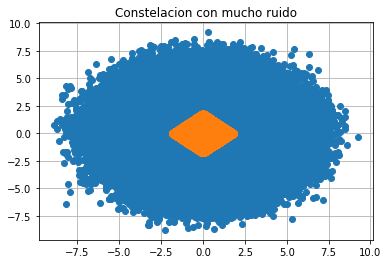

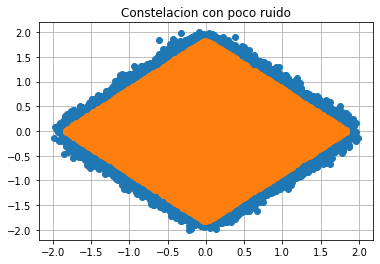

```python
ebno=-5 #Con mucho ruido
error_sum=0;
esno = ebno + 10*log(k,10)
w1=cpx_awgn(r_tx,esno,nsamp)

plt.figure()
plt.title('Constelacion con mucho ruido')
plt.plot(w1.real,w1.imag,"o")
plt.plot(r_tx.real,r_tx.imag,"o")
plt.grid()

ebno=20 #Con poco ruido
error_sum=0;
esno = ebno + 10*log(k,10)
w1=cpx_awgn(r_tx,esno,nsamp)


plt.figure()
plt.title('Constelacion con poco ruido')
plt.plot(w1.real,w1.imag,"o")
plt.plot(r_tx.real,r_tx.imag,"o")
plt.grid()
```

## Filtrado de la señal

Si el filtro de transmisión en un filtro raíz de coseno alzado, en recepción debe emplearse un filtro raíz de coseno alzado para que los filtros estén acoplados y eliminen la mayor cantidad de interferencia entre símbolos posible.

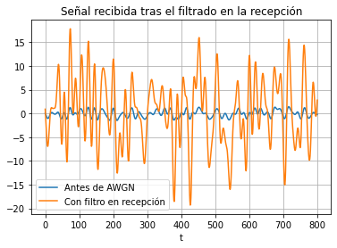

```python
ebno=-5 #Con mucho ruido
error_sum=0;
esno = ebno + 10*log(k,10)
w1=cpx_awgn(r_tx,esno,nsamp)

y_rx1=np.convolve(w1,filtro,mode='same')

plt.figure()
plt.title("Señal recibida tras el filtrado en la recepción")
plt.xlabel('t')
plt.plot(np.arange(0,100*nsamp),r_tx[0:100*nsamp])
plt.plot(np.arange(0,100*nsamp),y_rx1[0:100*nsamp])
plt.legend(("Antes de AWGN","Con filtro en recepción"))
plt.grid()
```

Si se compara la señal transmitida con la recibida son iguales salvo por la excepción de la amplitud que es mayor en el caso de la recepción. Esto se debe a las sumas entre el ruido y la convolución del filtro con la señal recibida con el ruido.

Aunque en el caso de la modulación PSK no haría falta, sin embargo, para la QAM es necesario normalizar en amplitud la señal tras el submuestreo del filtro comparándola con los símbolos transmitidos ya que, si no, el demodulador utilizado no realiza bien la detección debido a la forma en la que esta implementado.

m_rx=m_rx/np.linalg.norm(m_rx)*np.linalg.norm(m_tx)

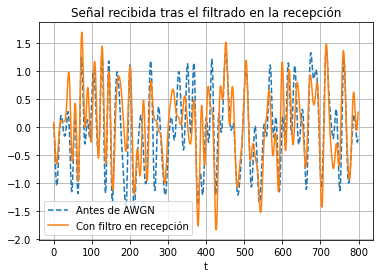

```python
plt.figure()
plt.title("Señal recibida tras el filtrado en la recepción")
plt.xlabel('t')
plt.plot(np.arange(0,100*nsamp),r_tx[0:100*nsamp],"--")
plt.plot(np.arange(0,100*nsamp),y_rx1[0:100*nsamp]/np.linalg.norm(y_rx1)*np.linalg.norm(r_tx))
plt.legend(("Antes de AWGN","Con filtro en recepción"))
plt.grid()
```

## Submuestreo de la señal

Una vez pasado por el filtro, se quitan todos las muestras en instantes intermedios del periodo de símbolo que se habían introducido en el sobremuestreo de la señal.

m_rx= downsample(y_rx,nsamp)

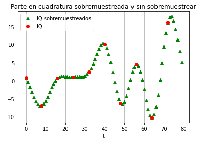

```python
m_rx1= downsample(y_rx1,nsamp)

plt.figure()
plt.xlabel('t')
plt.plot(np.arange(0,10*nsamp),y_rx1[0:10*nsamp],'^g')
plt.plot(np.arange(0,10*nsamp)[0:10*nsamp:nsamp],np.zeros(10)+m_rx1[0:10].real,"or")
plt.title('Parte en cuadratura sobremuestreada y sin sobremuestrear')
plt.legend(('IQ sobremuestreados','IQ'))
plt.grid()
```

## Demodulación de la señal

Para obtener los bits transmitidos se demodula con una codificación de hard-decision en la que no se intenta hacer ninguna corrección, sino que se demodula tal y como lo ha recibido.

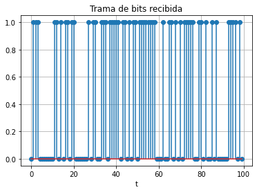

```python
x_rx1= mod1.demodulate(m_rx1,'hard')

plt.figure()
plt.title('Trama de bits recibida')
plt.xlabel('t')
t=np.arange(0,100)
plt.stem(t,x_rx1[0:100])
plt.grid()
```

## Cálculo de errores en la transmisión

Los errores en transmisión se calculan comparando los bits de transmisión y de recepción, siendo la tasa de error de bit el total de bits erróneos entre el total de bits

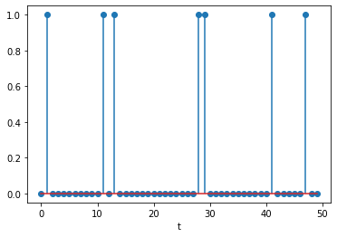

```
BER= numero de errores / numero total de bits = 71770/400000 = 0.179425
```

```python
plt.figure()
plt.xlabel('t')
error=np.zeros(len(x_tx))
bandera=0
c=0
for u,v in zip(x_tx,x_rx1):
    if u!=v:
        error[bandera]=1.
        c+=1
    else:
        error[bandera]=0.
    bandera+=1
plt.stem(t[0:50],error[0:50])
plt.show()

print(f"BER= numero de errores / numero total de bits = {c}/{len(x_tx)} = {c/len(x_tx)}")
```

De esta forma se calculará la gráfica de la BER respecto a la relación Eb/No del sistema. Como ya se ha visto, cuanto más pequeña sea mayor será la distorsión que se le aplique a la señal dando como resultado una peor calidad en la comunicación, por lo que la probabilidad de error será mayor que para Eb/No más grandes donde la distorsión será más pequeña y no un inconveniente para recibir la señal correctamente.

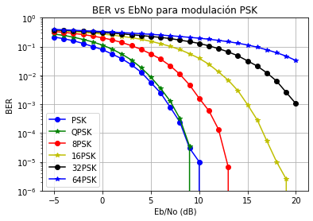

```python
import numpy as np
from commpy import PSKModem
from commpy import QAMModem
from scipy.special import erfc
import matplotlib.pyplot as plt
from math import log,sin,pi,sqrt
from sk_dsp_comm.sigsys import downsample,upsample,cpx_awgn
from sk_dsp_comm.digitalcom import sqrt_rc_imp,rc_imp,q_fctn


def PSK_BER(M,Ns,EbNo_MIN,EbNo_MAX,color,alpha):
    """
         Esta función devuelve las gráficas teóricas y simuladas de la BER
         en un sistema de radiocomunicaciones para una modulacion MPSK
         Dependiendo de los parámetros que se les pase evaluará el sistema
         de una forma distinta
         M: Número de símbolos de la constelación
         Ns: Número de bits transmitidos
         EbNo_MIN,EbNo_MAX: intervalos de evaluación de la BER
         color: parámetro añadido por estética para representar varias gráficas
         alpha: factor de roll-off de los filtros de transmisión y recepción
    """
    ##Definicion del intervalo de EbNo
    Eb_No_dB = np.arange(EbNo_MIN,EbNo_MAX+1)
    Eb_No_lin = 10**(Eb_No_dB/10.0)

    ##Se crea un objeto te tipo PSK
    mod1=PSKModem(M)
    k=mod1.num_bits_symbol

    ##Se crearán variables vacías para ir añadiendo los valores
    Pe = np.empty(np.shape(Eb_No_lin))
    BER = np.empty(np.shape(Eb_No_lin))

    ##Parámetros para el diseño del filtro
    Ts=1;
    Fs=8; #Cuanto más suba Fs, más se acercará la BER a la gráfica teórica
    nsamp=Fs*Ts; #Muestras por simbolo

    ##Diseño del filtro
    filtro= sqrt_rc_imp(nsamp,alpha)

    ##Crear el vector de datos binarios
    x_tx = np.random.randint(0, 2, k*Ns) # Ristra de bits binaria y aleatoria

    ##Aplicar la modulacion PSK a los bits
    m_tx=mod1.modulate(x_tx)

    ##Sobremuestrear y filtrar los datos de entrada
    y_tx=upsample(m_tx,nsamp)
    r_tx=np.convolve(y_tx,filtro,mode='same')

    ##Pasar la señal por un canal AWGN
    loop=0;
    for ebno in Eb_No_dB:
        error_sum=0;
        esno = ebno + 10*log(k,10)
        w=cpx_awgn(r_tx,esno,nsamp)

        ##Filtrar y submuestrear
        y_rx=np.convolve(w,filtro,mode='same')
        ##Submuestrear la señal recibida
        m_rx= downsample(y_rx,nsamp)
        ##Demodular la señal recibida
        x_rx= mod1.demodulate(m_rx,'hard')
        total_sent=len(x_rx)
        ##Se comprueban los errores comparando la transmisión con la recepción
        for u,v in zip(x_tx,x_rx):
            if u!=v:
                error_sum+=1

        ##Cálculo de la Tasa de Error por Bit
        BER[loop] = float(error_sum)/float(total_sent)
        loop += 1

    plt.ylim(10**-6)
    plt.semilogy(Eb_No_dB, BER,color)

EbNo_MIN=-5
EbNo_MAX=20
alpha=0.22
Ns=100000

plt.figure()
plt.title("BER vs EbNo para modulación PSK")

PSK_BER(2,Ns,EbNo_MIN,EbNo_MAX,"-ob",alpha)
PSK_BER(4,Ns,EbNo_MIN,EbNo_MAX,"-*g",alpha)
PSK_BER(8,Ns,EbNo_MIN,EbNo_MAX,"-or",alpha)
PSK_BER(16,Ns,EbNo_MIN,EbNo_MAX,"-*y",alpha)
PSK_BER(32,Ns,EbNo_MIN,EbNo_MAX,"-ok",alpha)
PSK_BER(64,Ns,EbNo_MIN,EbNo_MAX,"-*b",alpha)
plt.grid()
plt.legend(("PSK","QPSK","8PSK","16PSK","32PSK","64PSK"))
plt.xlabel("Eb/No (dB)")
plt.ylabel("BER")
plt.show()
```

## Simulación de un sistema de radiocomunicación QAM

Para implementar el sistema de radiocomunicación QAM se sigue la misma lógica y paso a paso que se describió anterior mente en el sistema PSK, por lo que se obviarán los pasos y se pasará a realizar la gráfica de la BER respecto a la relación Eb/No del sistema QAM

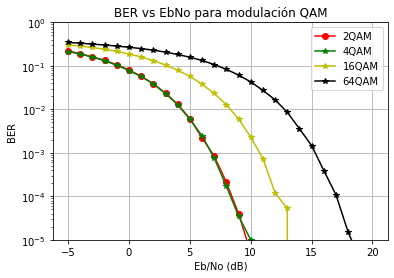

```python
def QAM_BER(M,Ns,EbNo_MIN,EbNo_MAX,color,alpha):
    """
        Esta función devuelve las gráficas teóricas y simuladas de la BER
        en un sistema de radiocomunicaciones para una modulacion MQAM
        Dependiendo de los parámetros que se les pase evaluará el sistema
        de una forma distinta
        M: Número de símbolos de la constelación
        Ns: Número de bits transmitidos
        EbNo_MIN,EbNo_MAX: intervalos de evaluación de la BER
        color: parámetro añadido por estética para representar varias gráficas
        alpha: factor de roll-off de los filtros de transmisión y recepción
    """
    ##Definicion del intervalo de EbNo
    Eb_No_dB = np.arange(EbNo_MIN,EbNo_MAX+1)
    Eb_No_lin = 10**(Eb_No_dB/10.0)

    ##Se crea un objeto te tipo QAM
    mod1=QAMModem(M)
    k=mod1.num_bits_symbol

    ##Se crearán variables vacías para ir añadiendo informacion
    Pe = np.empty(np.shape(Eb_No_lin))
    BER = np.empty(np.shape(Eb_No_lin))

    ##Parámetros para el diseño del filtro
    Ts=1;
    Fs=8; #Cuanto más suba Fs, más se acercará la BER a la gráfica teórica
    nsamp=Fs*Ts; #Muestras por simbolo

    ##Diseño del filtro
    filtro= sqrt_rc_imp(nsamp,alpha)

    ##Crear el vector de datos binarios
    x_tx = np.random.randint(0, 2, k*Ns) # Ristra de bits binaria y aleatoria

    ##Aplicar la modulacion QAM a los bits
    m_tx=mod1.modulate(x_tx)

    ##Sobremuestrear y filtrar los datos de entrada
    y_tx=upsample(m_tx,nsamp)
    r_tx=np.convolve(y_tx,filtro,mode='same')

    ##Pasar la señal por un canal AWGN
    loop=0;
    for ebno in Eb_No_dB:
        error_sum=0;
        esno = ebno + 10*log(k,10)
        w=cpx_awgn(r_tx,esno,nsamp)

        ##Filtrar la señal tras pasarla por el canal
        y_rx=np.convolve(w,filtro,mode='same')

        ##Submuestrear la señal recibida y linealizarla
        m_rx= downsample(y_rx,nsamp)
        m_rx=m_rx/np.linalg.norm(m_rx)*np.linalg.norm(m_tx)

        ##Demodular la señal recibida
        x_rx= mod1.demodulate(m_rx,'hard')
        total_sent=len(x_rx)

        #Se comprueban los errores comparando la transmisión con la recepción
        for u,v in zip(x_tx,x_rx):
            if u!=v:
                error_sum+=1;

        ##Cálculo de la Tasa de Error por Bit
        BER[loop] = float(error_sum)/float(total_sent)
        loop+=1
    plt.ylim(10**-5)
    plt.semilogy(Eb_No_dB, BER,color)

EbNo_MIN=-5
EbNo_MAX=20
alpha=0.22
Ns=100000

plt.figure()
plt.title("BER vs EbNo para modulación QAM")

QAM_BER(2,Ns,EbNo_MIN,EbNo_MAX,"-or",alpha)
QAM_BER(4,Ns,EbNo_MIN,EbNo_MAX,"-*g",alpha)
#QAM_BER(8,Ns,EbNo_MIN,EbNo_MAX,"-or",alpha)
QAM_BER(16,Ns,EbNo_MIN,EbNo_MAX,"-*y",alpha)
#QAM_BER(32,Ns,EbNo_MIN,EbNo_MAX,"-ok",alpha)
QAM_BER(64,Ns,EbNo_MIN,EbNo_MAX,"-*k",alpha)
plt.grid(True)
plt.legend(("2QAM","4QAM","16QAM","64QAM"))
plt.xlabel("Eb/No (dB)")
plt.ylabel("BER")
plt.show()
```

## Conclusiones

Implementando un sistema de radiocomunicación con filtrado raíz de coseno alzado para minimizar la ISI ya que este es de la familia del coseno alzado, se obtiene que los filtros están adaptados tanto en transmisión como en recepción. Con este caso se busca conseguir que la tasa de error de bit del sistema sea la mínima posible y se acerque lo más posible a la tasa de error de bit teórica.

Las PSK son más eficientes para M más pequeñas además de ser más fáciles de implementar ya que la distancia entre todos los puntos es la misma. Sin embargo, para M más grandes conviene utilizar QAM ya que minimiza la probabilidad de error respecto a una M, puesto que al tener componentes en cuadratura y fase se pueden separar más los símbolos entre sí para energías más grandes.

Otro parámetro importante para este caso es la frecuencia utilizada para el filtro, ya que, a mayor frecuencia de muestreo, se obtendrá más precisión en las muestras transmitidas y, por ende, mejorará la probabilidad de error. Esta frecuencia debe cumplir las condiciones de Nyquist para minimizar la interferencia entre símbolo introducida entre la transmisión de los símbolos. Con este parámetro se obtendrá el valor del número de muestras por símbolo añadidas.